# R Intermediate Course 2026

Session 3 :: Data Visualization with ggplot2

Dr. Debasish Mukherjee, Dr. Ulrike Goebel, Dr. Ali Abdallah

Bioinformatics Core Facility CECAD

2026-09-24

**Session 3 :: Data Visualization with ggplot2**

## Learning objectives

By the end of this session you should be able to:

- Say **why** `ggplot2` is worth learning on top of base R graphics.
- Read a `ggplot2` call as three parts: **data**, **aesthetic mapping**, and **geoms**.
- Reproduce the everyday plots you already make in base R — scatter, bar, histogram, boxplot — in `ggplot2`, and see the two side by side.
- Add a grouping variable, split into panels, and fit a line per group with a small change to the code.
- Save a figure at a resolution suitable for a manuscript.

# Why ggplot2?

**The motivation**

## The same scatter plot, two ways

**Base R**

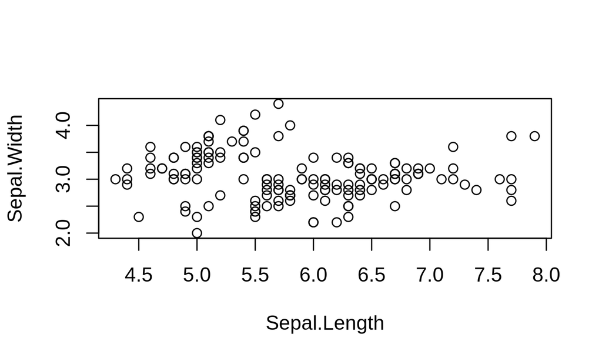

```r
plot(Sepal.Width ~ Sepal.Length, data = iris)
```

**ggplot2**

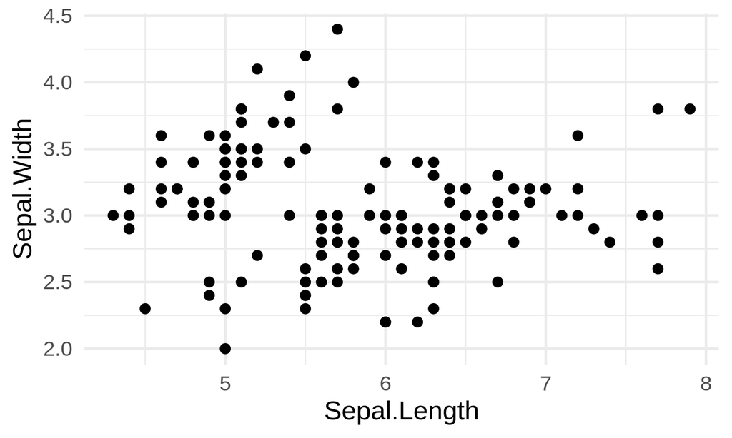

```r
ggplot(iris, aes(Sepal.Length, Sepal.Width)) +
  geom_point()
```

For a single, simple plot the two are close. The difference shows up as soon as the plot needs to grow.

## Quick check — fixed colour vs mapped colour

Before we go further, compare these two base R calls:

```r
cols <- c("#E69F00", "#0072B2", "#009E73")

# A
plot(iris$Sepal.Length, iris$Sepal.Width, col = "blue")
# B
plot(iris$Sepal.Length, iris$Sepal.Width, col = cols[iris$Species])
```

- Your answer first
- Answer

One of these sets a **fixed** colour; the other **looks up** a colour **per observation** from `Species`. Which is which, and what would you need to add to B to also get a legend?

**A** is fixed — every point is the same blue, no matter what. **B** is mapped — the colour depends on the data, so it varies row by row, and B is also the one that needs you to build a legend by hand in base R. `ggplot2` makes exactly this distinction explicit: mappings go inside `aes()`, fixed values go outside it. We will put this to work right away.

## Legends, panels, and styling

Three common tasks when a plot grows:

1. **Legends:** base R uses `legend()`; ggplot2 generates guides from mappings.
2. **Panels:** base R uses layouts and separate plotting calls; ggplot2 uses facets.
3. **Styling:** base R shares settings through `par()` or helpers; ggplot2 uses themes.

We will compare these workflows using the same data.

## The idea: a grammar of graphics

A `ggplot2` plot is built from a few named pieces:

| Piece | Question it answers | Example |
| --- | --- | --- |
| **data** | Which data frame? | `iris` |
| **aesthetic mapping** (`aes`) | Which column drives which visual property? | `x = Sepal.Length`, `colour = Species` |
| **geom** | How should the data be displayed? | `geom_point()`, `geom_bar()` |
| **facet** | Split into panels by which variable? | `facet_wrap(~ Species)` |
| **scale** | How do data values map to a visual range — position, colour, size? | `scale_colour_*()`, `scale_x_log10()` |
| **theme** | How does the plot look — fonts, gridlines, background — independent of the data? | `theme_minimal()`, `theme_classic()` |

Some geoms display individual observations; others display summaries. Layers inherit data and mappings from `ggplot()` unless overridden.

## Anatomy of a `ggplot()` call

```r
ggplot(data = iris,                                  # 1. the data
       mapping = aes(x = Sepal.Length,               # 2. map columns
                     y = Sepal.Width,                #    to visual
                     colour = Species)) +            #    properties
  geom_point() +                                     # 3. draw points
  labs(x = "Sepal length (cm)",                      # 4. labels
       y = "Sepal width (cm)")
```

- `data` and `mapping` set once in `ggplot()` are inherited by every layer, unless a layer overrides them.
- Use `+` to add layers or settings. Later drawing layers appear on top.
- `aes()` is for **mappings from data**. A fixed value (all points blue) goes **outside** `aes()`.

# Feature by feature

**base R on the left, ggplot2 on the right**

## Colour and legend from a variable

**Base R** — formula interface, own legend

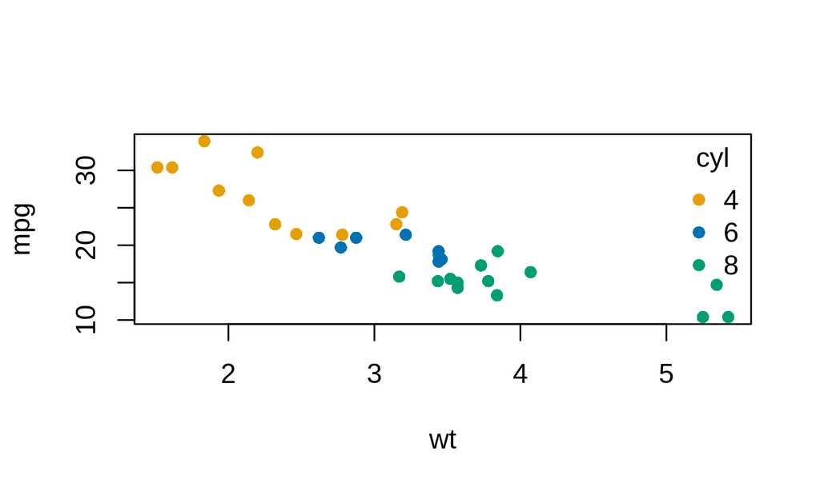

```r
cyl_f <- factor(mtcars$cyl)
cols  <- c("#E69F00", "#0072B2", "#009E73")
plot(mpg ~ wt, data = mtcars,
     col = cols[cyl_f], pch = 16)
legend("topright", legend = levels(cyl_f),
       col = cols, pch = 16,
       title = "cyl", bty = "n")
```

**ggplot2** — one mapping, legend appears

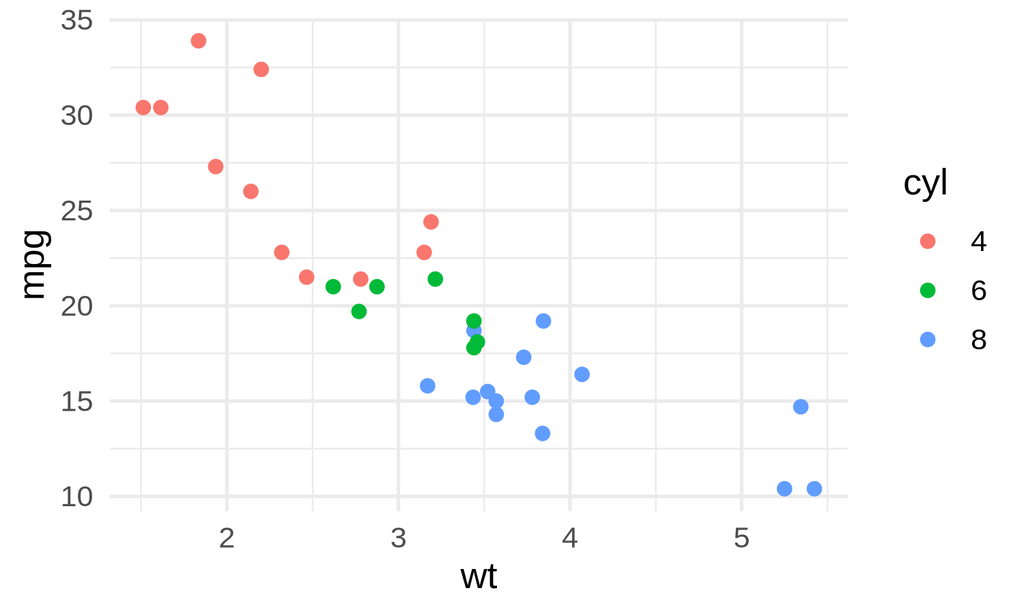

```r
ggplot(mtcars, aes(wt, mpg,
                   colour = factor(cyl))) +
  geom_point() +
  labs(colour = "cyl")
```

Both plots use column names for axis labels. In ggplot2, mapping `colour = factor(cyl)` assigns colours and creates the legend.

## Bar chart of counts

**Base R** — tabulate first, then plot

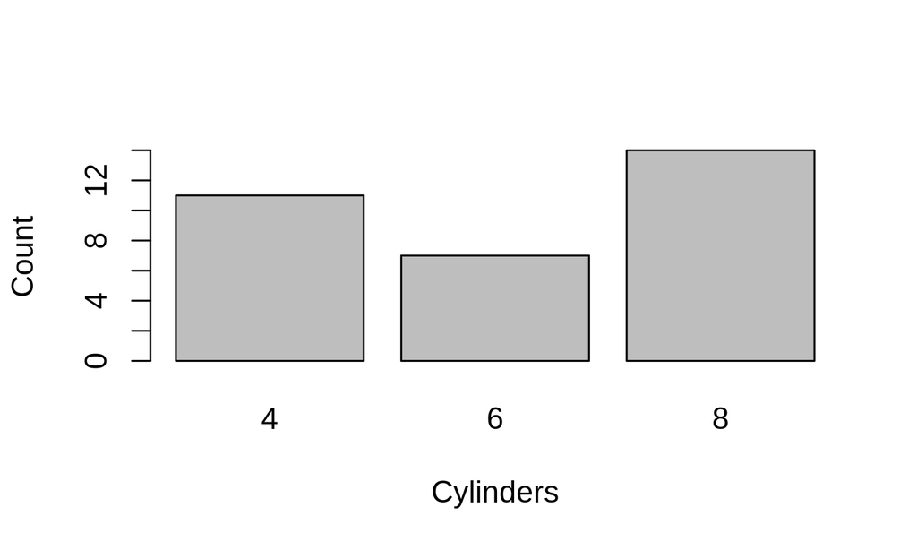

```r
tab <- table(mtcars$cyl)
barplot(tab,
        xlab = "Cylinders",
        ylab = "Count")
```

**ggplot2** — counting is built in

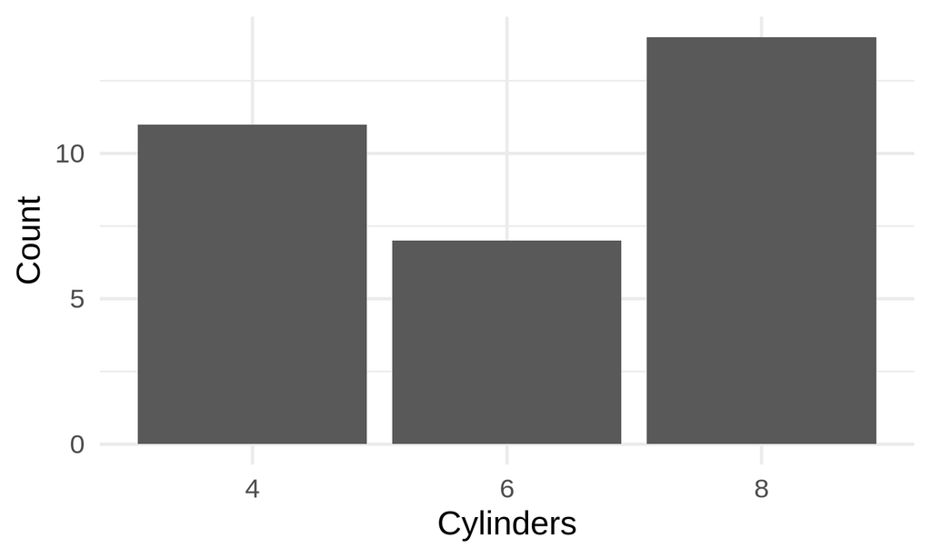

```r
ggplot(mtcars, aes(factor(cyl))) +
  geom_bar() +
  labs(x = "Cylinders", y = "Count")
```

`geom_bar()` counts the rows in each category for you. If you already have the numbers, use `geom_col()` instead.

## Histogram

Define the bin boundaries once for both plots:

```r
brks <- seq(10, 35, by = 2.5)
```

**Base R**

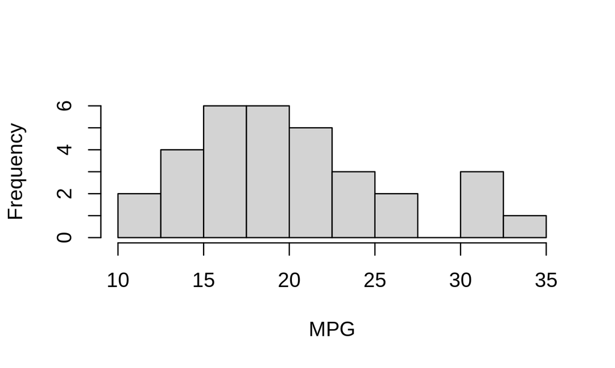

```r
hist(mtcars$mpg, breaks = brks,
     xlab = "MPG", main = "")
```

**ggplot2**

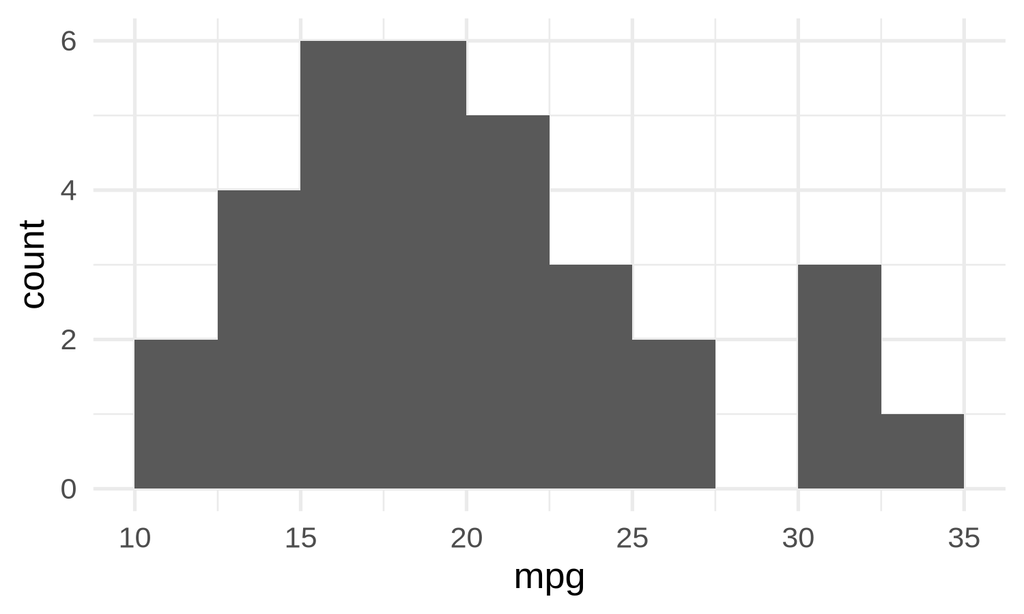

```r
ggplot(mtcars, aes(mpg)) +
  geom_histogram(breaks = brks)
```

Both plots use the same explicit breakpoints, so the bins are comparable.

## Boxplot by group

**Base R** — formula interface

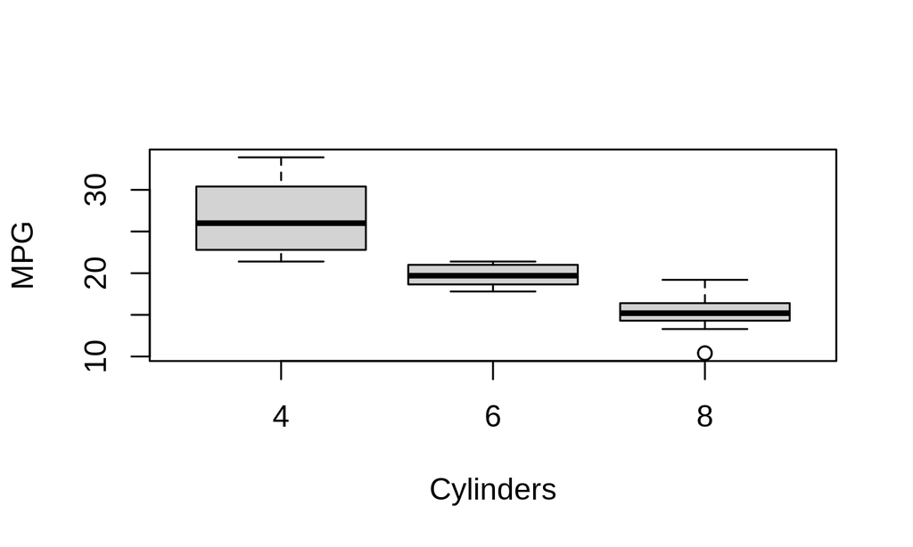

```r
boxplot(mpg ~ cyl, data = mtcars,
        xlab = "Cylinders", ylab = "MPG")
```

**ggplot2** — x and y as a mapping

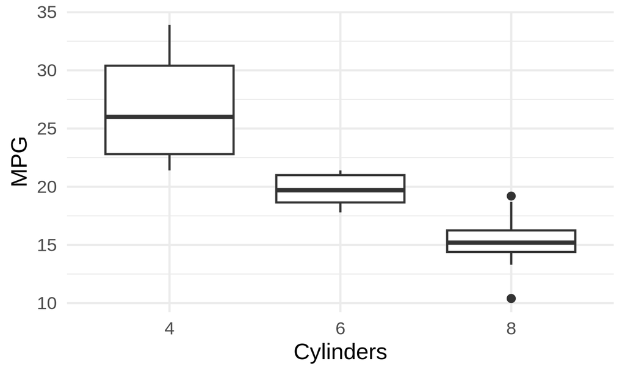

```r
ggplot(mtcars, aes(factor(cyl), mpg)) +
  geom_boxplot() +
  labs(x = "Cylinders", y = "MPG")
```

The base R formula `mpg ~ cyl` becomes the mapping `aes(factor(cyl), mpg)`.

## Small multiples: base R code

Set up the panels, use shared limits, and plot each species.

```r
op <- par(mfrow = c(1, 3), mar = c(4, 4, 2, 1))
xr <- range(iris$Sepal.Length)
yr <- range(iris$Sepal.Width)
for (sp in levels(iris$Species)) {
  plot(Sepal.Width ~ Sepal.Length, data = iris,
       subset = Species == sp,
       xlim = xr, ylim = yr, main = sp, pch = 16)
}
par(op)
```

## Small multiples: ggplot2 code

```r
ggplot(iris, aes(Sepal.Length, Sepal.Width)) +
  geom_point() +
  facet_wrap(~ Species)
```

`facet_wrap()` handles the panel layout, labels, and shared scales.

## Small multiples: compare the output

**Base R**

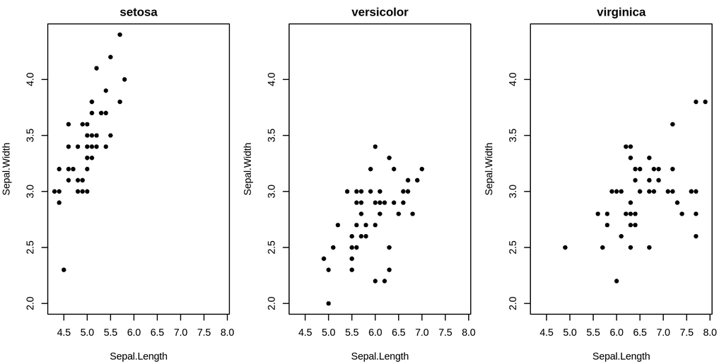

**ggplot2**

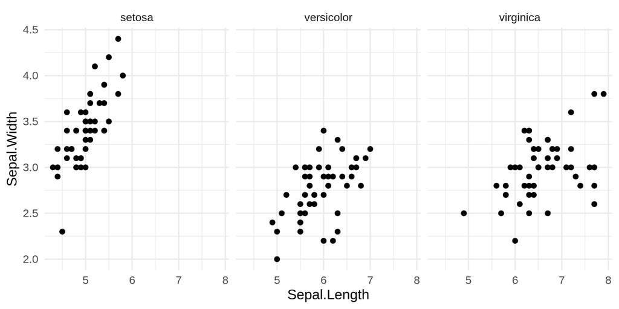

Both show one panel per species with common limits across panels.

## A fitted line per group

**Base R** — fit and draw each line

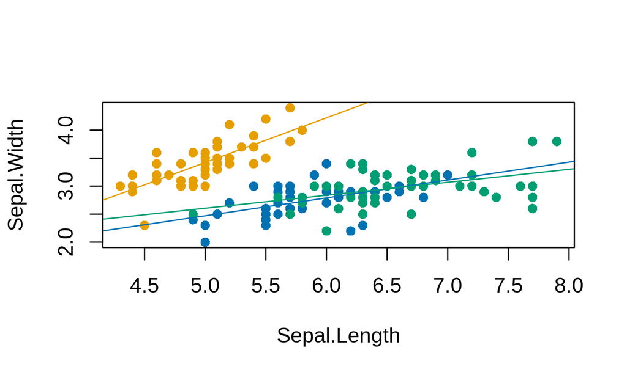

```r
cols  <- c("#E69F00", "#0072B2", "#009E73")
sp    <- iris$Species
plot(Sepal.Width ~ Sepal.Length, data = iris,
     col = cols[sp], pch = 16)
for (i in levels(sp)) {
  d <- iris[sp == i, ]
  abline(lm(Sepal.Width ~ Sepal.Length, d),
         col = cols[which(levels(sp) == i)])
}
```

**ggplot2** — add a smooth layer

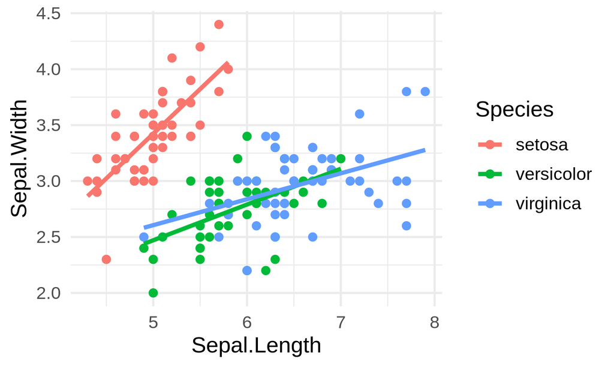

```r
ggplot(iris, aes(Sepal.Length, Sepal.Width,
                 colour = Species)) +
  geom_point() +
  geom_smooth(method = "lm", se = FALSE)
```

`geom_smooth(method = "lm")` fits one line per colour group, because the `colour = Species` mapping already split the data — the same fit the base R loop builds by hand.

## Styling and themes

**Base R** — share settings with `par()`

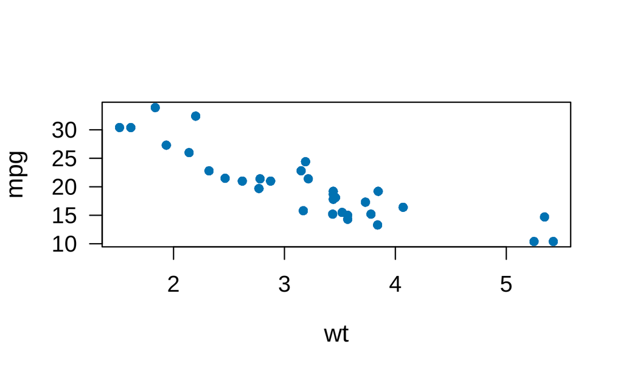

```r
op <- par(cex.lab = 1.2, cex.axis = 1.1, las = 1)
plot(mpg ~ wt, data = mtcars,
     pch = 16, col = "#0072B2")
```

```r
par(op)
```

**ggplot2** — a named, reusable theme

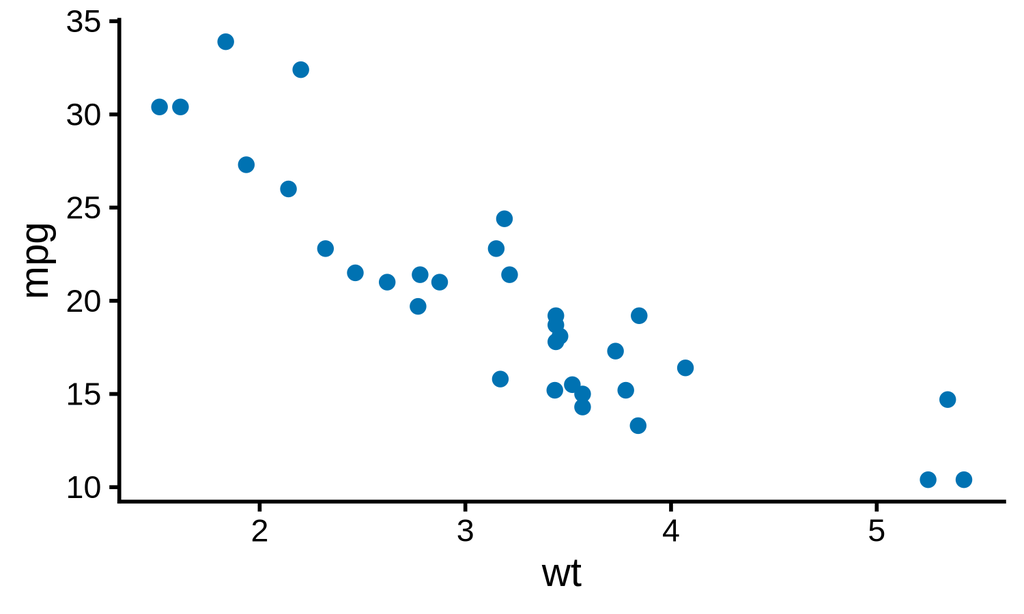

```r
ggplot(mtcars, aes(wt, mpg)) +
  geom_point(colour = "#0072B2") +
  theme_classic(base_size = 14)
```

Both systems support reusable styling. ggplot2 packages plot styling in named theme objects, such as `theme_classic()`.

The point colour is fixed outside `aes()`; it is a layer setting.

## A plot you can keep, not just draw

`plot()` writes straight to the graphics device — nothing is left afterward to reuse. A `ggplot2` call instead **returns an object**.

```r
p  <- ggplot(mtcars, aes(wt, mpg)) + geom_point()
p2 <- p + facet_wrap(~ cyl)   # p2 is p, extended
p                              # p itself is unchanged
```

- `+` returns a **new** object rather than changing `p` in place — `p2` gains the facets, `p` does not.
- Storing a plot in a variable lets you **reuse** it: display it, save several versions, or pass it into a function — build once, use for several purposes.
- A bare `p` auto-prints at the console or top level of a chunk. Inside a **function or loop**, that does not happen automatically — call `print(p)` explicitly.

## Save a plot object

**Base R** — open a device, plot, close it

```r
png("figure.png", width = 8, height = 5,
    units = "in", res = 300)
plot(mpg ~ wt, data = mtcars)
dev.off()
```

**ggplot2** — save the plot object `p`

```r
p <- ggplot(mtcars, aes(wt, mpg)) +
  geom_point()

ggsave("figure.png", p,
       width = 8, height = 5,
       units = "in", dpi = 300)
```

Choose dimensions, file format, and raster resolution to match the publication’s requirements. `ggsave()` infers the format from the extension.

## When base R is still a good choice

`ggplot2` is not a replacement for every situation:

- A **quick look** at a vector while you work — `plot()` or `hist()` is fast and needs no packages.
- **Base R objects** with dedicated plot methods, e.g. `plot(hclust_result)` for a dendrogram or `image()` for a matrix.
- Very **custom, one-off** diagrams where you want to place each element by hand.

The clearest advantages shown here are automatic legends, faceting, and reusing mappings across layers. Both systems can produce publication figures.

## Summary

**Three things to take away**

1. A `ggplot2` plot is **data + an aesthetic mapping + geoms**, combined with `+`.
2. **Mappings** coordinate colours, groups, and legends; **facets** split the data into panels.
3. `aes()` is for values that **come from the data**; fixed values go **outside** `aes()`.

Extend the same structure with new geoms, scales, and themes.